# MALASPINA SRF | 10 amplicons samples - ss5724 | Bacteria

Logares R. & Rubinat-Ripoll L.

24.01.2015

# 1) Data overview

Samples with less than 5724 reads are removed:

```
##   [1] "MD1013" "MD1035" "MD1042" "MD1080" "MD1100" "MD111"  "MD1125"
##   [8] "MD1143" "MD1176" "MD1186" "MD1209" "MD1222" "MD1246" "MD1254"
##  [15] "MD1260" "MD1293" "MD1302" "MD1318" "MD1324" "MD1331" "MD1354"
##  [22] "MD1368" "MD1398" "MD141"  "MD1421" "MD1425" "MD1459" "MD1475"
##  [29] "MD1479" "MD1490" "MD1517" "MD1537" "MD1559" "MD1589" "MD1607"
##  [36] "MD1629" "MD1672" "MD1700" "MD1724" "MD1744" "MD1772" "MD1798"
##  [43] "MD1811" "MD1857" "MD1885" "MD1887" "MD1928" "MD1956" "MD1964"
##  [50] "MD196"  "MD2004" "MD2008" "MD202"  "MD2047" "MD2051" "MD2094"
##  [57] "MD2111" "MD214"  "MD2151" "MD2155" "MD2215" "MD2243" "MD2247"
##  [64] "MD2304" "MD2332" "MD2340" "MD2380" "MD2408" "MD2436" "MD2448"
##  [71] "MD2474" "MD2516" "MD254"  "MD2562" "MD2594" "MD2624" "MD2662"
##  [78] "MD266"  "MD2695" "MD2723" "MD2751" "MD2761" "MD2821" "MD285"
##  [85] "MD2864" "MD28"   "MD2926" "MD2956" "MD2973" "MD311"  "MD346"
##  [92] "MD366"  "MD389"  "MD40"   "MD417"  "MD439"  "MD458"  "MD486"
##  [99] "MD506"  "MD528"  "MD52"   "MD550"  "MD575"  "MD591"  "MD60"
## [106] "MD621"  "MD646"  "MD64"   "MD664"  "MD684"  "MD712"  "MD734"
## [113] "MD753"  "MD778"  "MD806"  "MD834"  "MD854"  "MD876"  "MD897"
## [120] "MD916"  "MD940"  "MD962"  "MD985"  "MD98"
```

```
## [1] 1178  124
```

```
##          MD1013 MD1035 MD1042 MD1080 MD1100
## OTU_5       162    238    486   1639    653
## OTU_1     13804   9239  37085  24192  36066
## OTU_596      20     75    100    502    118
## OTU_1295      1      1      7      1      0
## OTU_36       59    196    210    346     33
```

```
## named numeric(0)
```

Table dimensions and content outline:

```
## [1] 1178   10
```

```
##          MD311 MD528 MD778 MD1176 MD1421
## OTU_5      374  4473  2699    112   2928
## OTU_1    57800  7475  6773  12357   2007
## OTU_596     71    81    26     20     27
## OTU_1295     6     3     0      0      0
## OTU_36     231   307    13      6     11
```

Minimum number of reads per station:

```r
min(colSums(tb10))
```

```
## [1] 5724
```

Maximum number of reads per station:

```r
max(colSums(tb10))
```

```
## [1] 98167
```

Identification of station with higher number of reads:

```r
amplicons_per_sample<-colSums(tb10)
amplicons_per_sample[which(colSums(tb10)>98000)]
```

```
## MD311
## 98167
```

Overall reads per sample:

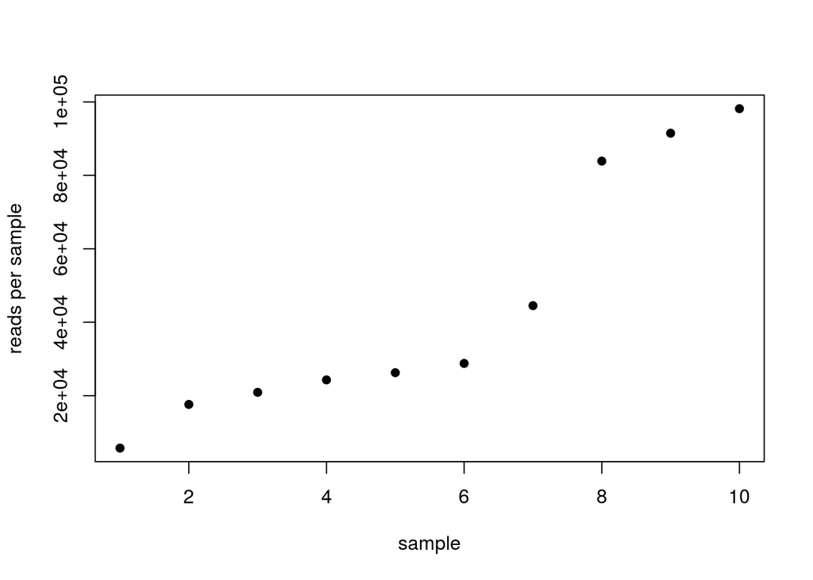

# 2) Normalization to 5724 reads per sample

Let’s normalize the original dataset by randomly subsampling 5724 reads in each station:

```r
library(vegan)
tb10_t<-t(tb10)
otu_tb10_t_ss5724<-rrarefy(tb10_t, 5724)
```

The normalized table shows the following dimensions and format:

```
## [1]   10 1178
```

```
##        OTU_5 OTU_1 OTU_596 OTU_1295 OTU_36
## MD311     18  3375       3        0     20
## MD528    269   467       6        0     18
## MD778    589  1501       3        0      2
## MD1176    26  3359       5        0      2
## MD1421   944   635      14        0      1
```

Its content fits with the expected normalization values (5724 reads per station):

```r
rowSums(otu_tb10_t_ss5724)
```

```
##  MD311  MD528  MD778 MD1176 MD1421 MD1517 MD1672 MD1857 MD2243 MD2821
##   5724   5724   5724   5724   5724   5724   5724   5724   5724   5724
```

Let’s check out how many OTUs don’t appear in the new table:

```r
length(which(colSums(otu_tb10_t_ss5724)==0))
```

```
## [1] 587
```

There are 587 OTUs that don’t show any occurrence in the normalized data. Let’s remove them from the table and take a look at its final dimensions:

```r
otu_tb10_t_ss5724_no_cero<-otu_tb10_t_ss5724[,-(which(colSums(otu_tb10_t_ss5724)==0))]
dim(otu_tb10_t_ss5724_no_cero)
```

```
## [1]  10 591
```

Datasets summary:

tb10_t –> 10 1178

otu_tb10_t_ss5724_no_cero –> 10 591

# 3) General community analysis

## 3.1) Richness and evenness (Shannon index)

Most of the samples take Shannon Index values between 2.25 and 3.25:

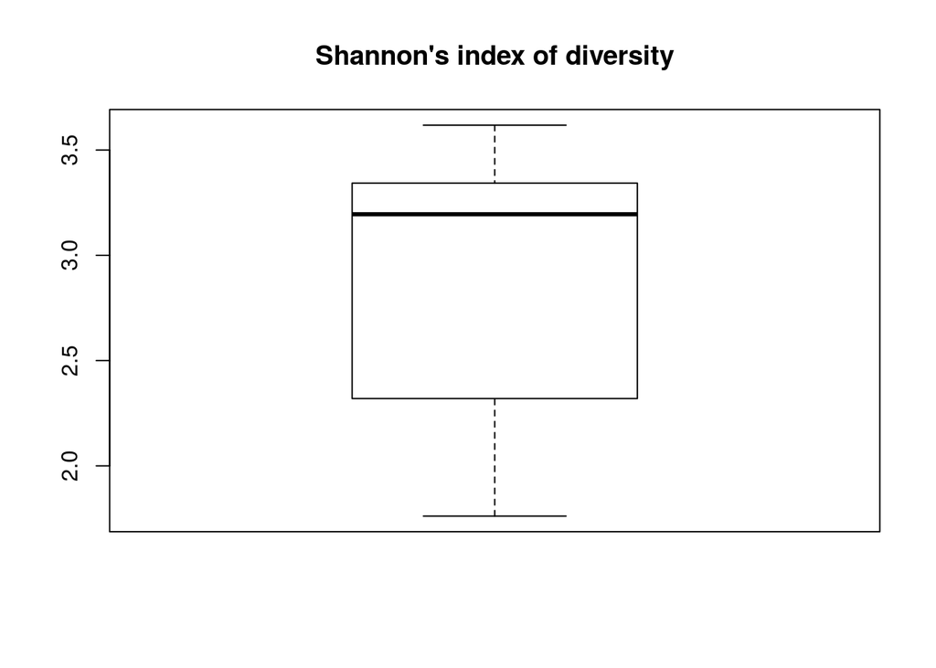

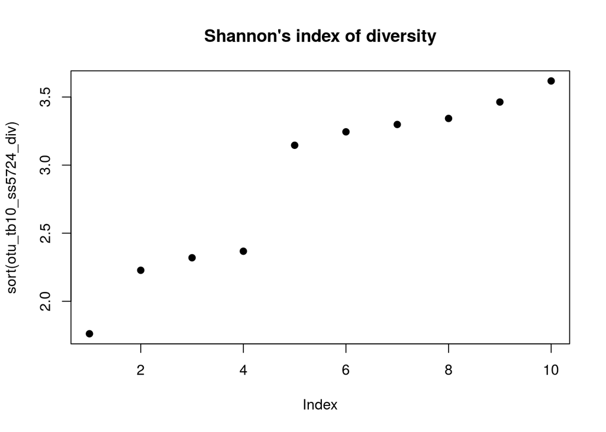

## 3.2) Richness: OTU number

Lowest number of OTUs per sample:

```
## [1] 156
```

Maximum number of OTUs per sample:

```
## [1] 266
```

In most of the samples, we can identify between 200 and 230 OTUs:

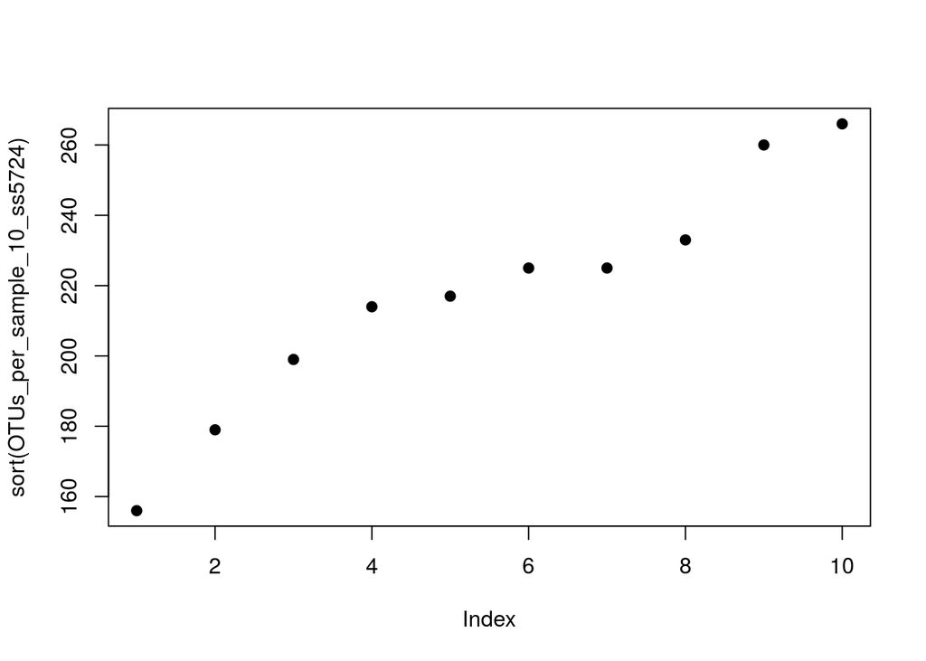

```r
plot(sort(OTUs_per_sample_10_ss5724), pch=19)
```

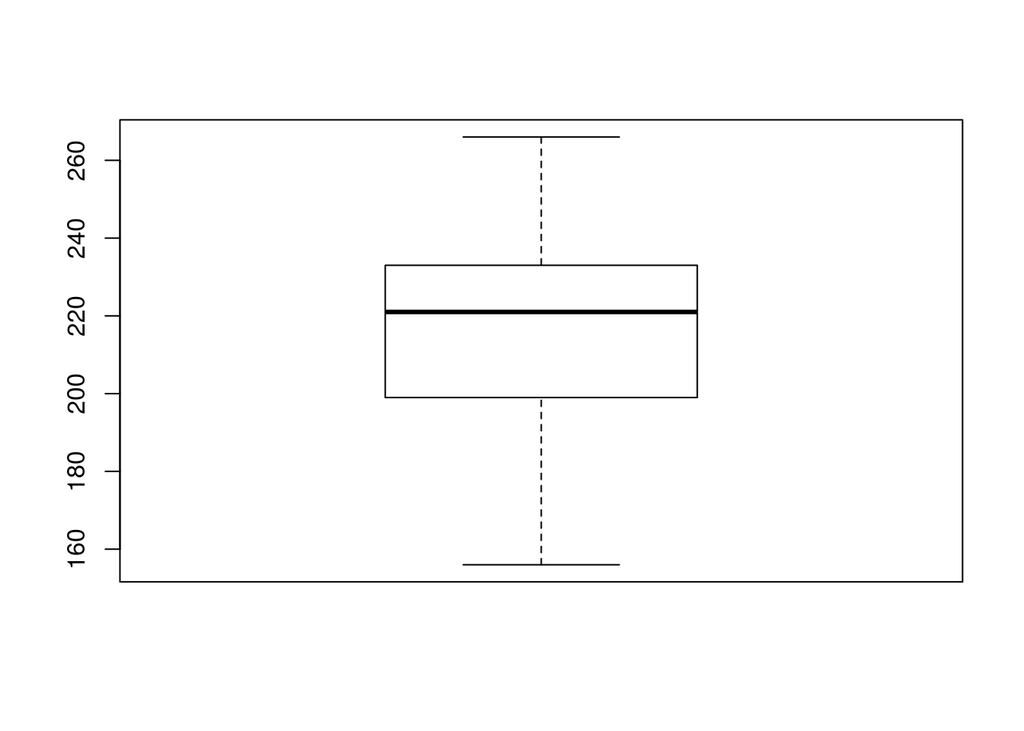

```r
boxplot(OTUs_per_sample_10_ss5724, pch=19)
```

## 3.3) Index of evenness

### 3.3.1) Pielou’s index

```r
pielou_evenness_10_ss5724 <- otu_tb10_ss5724_div/log(OTUs_per_sample_10_ss5724)
```

The Pielou index (constrained between 0 and 1) takes values closer to 1 as the variation of species proportion in a sample decreases. Most of our samples get values between 0.425 and 0.625, meaning that the numerical composition of different OTUs within our samples is relatively similar:

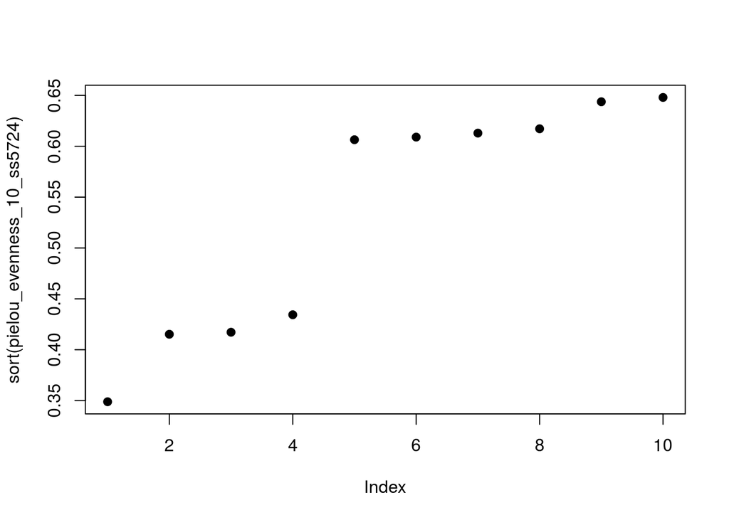

```r
plot(sort(pielou_evenness_10_ss5724), pch=19)
```

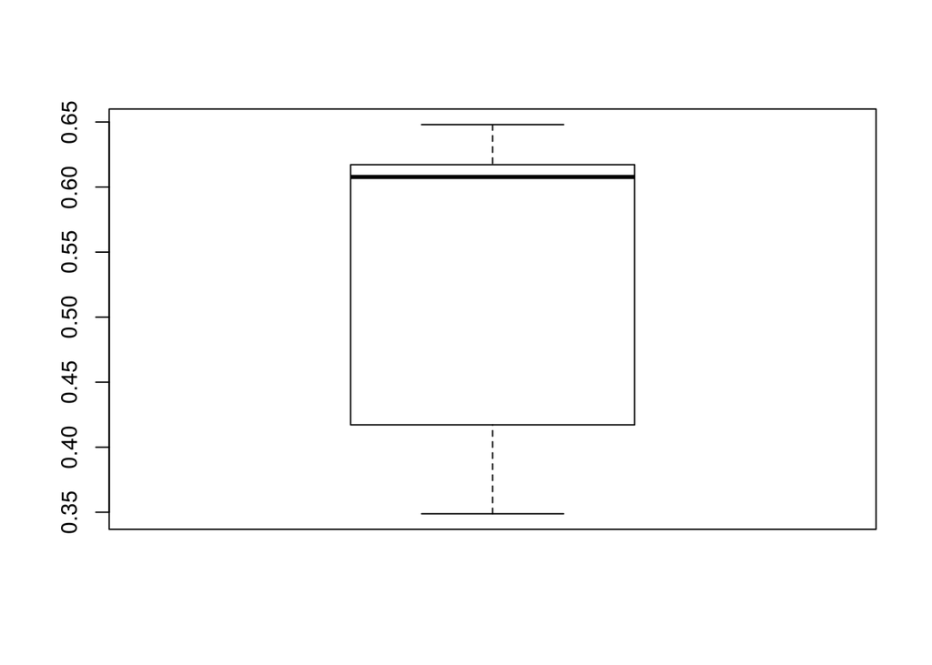

```r
boxplot(pielou_evenness_10_ss5724, pch=19)
```

The OTU_1, with 20053 reads, is the most abundant in the overall dataset:

```r
head(sort(colSums(otu_tb10_t_ss5724_no_cero), decreasing=T), n=10L)
```

```
##   OTU_1   OTU_2   OTU_4   OTU_3   OTU_5   OTU_6  OTU_10  OTU_23  OTU_13
##   20053    8941    2856    2286    2248    1054     658     555     507
## OTU_368
##     485
```

Most of the OTUs show few occurrences, but we don’t observe the presence of a massive group of rare OTUs:

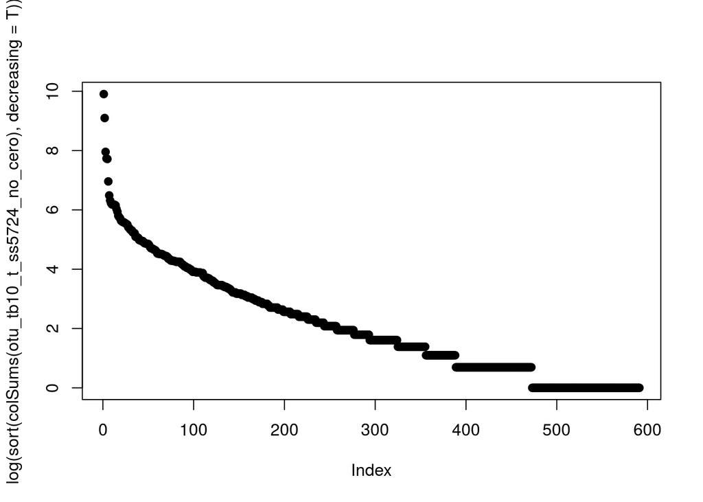

```r
plot(log(sort(colSums(otu_tb10_t_ss5724_no_cero), decreasing=T)), pch=19)
```

## 3.4) Abundance Models

### 3.4.1) Rank-Abundance or Dominance/Diversity Model (“radfit”)

The OTUs abundance distribution fits relativelly close to log-normal model.

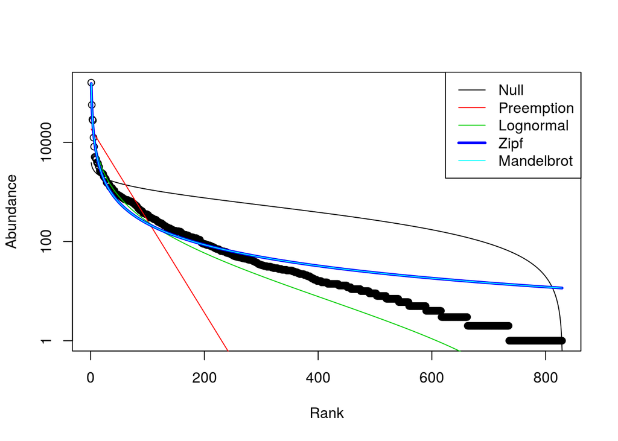

### 3.4.2) Preston’s Lognormal Model

According to Preston’s lognormal model fit into species frequencies groups, we’re missing ~130 species:

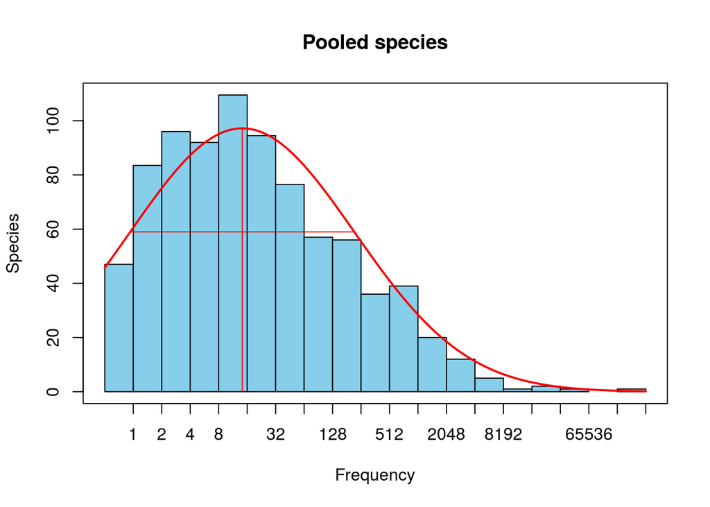

```r
otu_tb10_min5724_prestonfit<-prestonfit(colSums(tb10_t))
plot(otu_tb10_min5724_prestonfit, main="Pooled species")
```

```r
veiledspec(otu_tb10_min5724_prestonfit)
```

```
## Extrapolated     Observed       Veiled
##     958.9718     829.0000     129.9718
```

When computing Preston’s lognormal model fit without pooling data into groups, we seem to miss ~118 species:

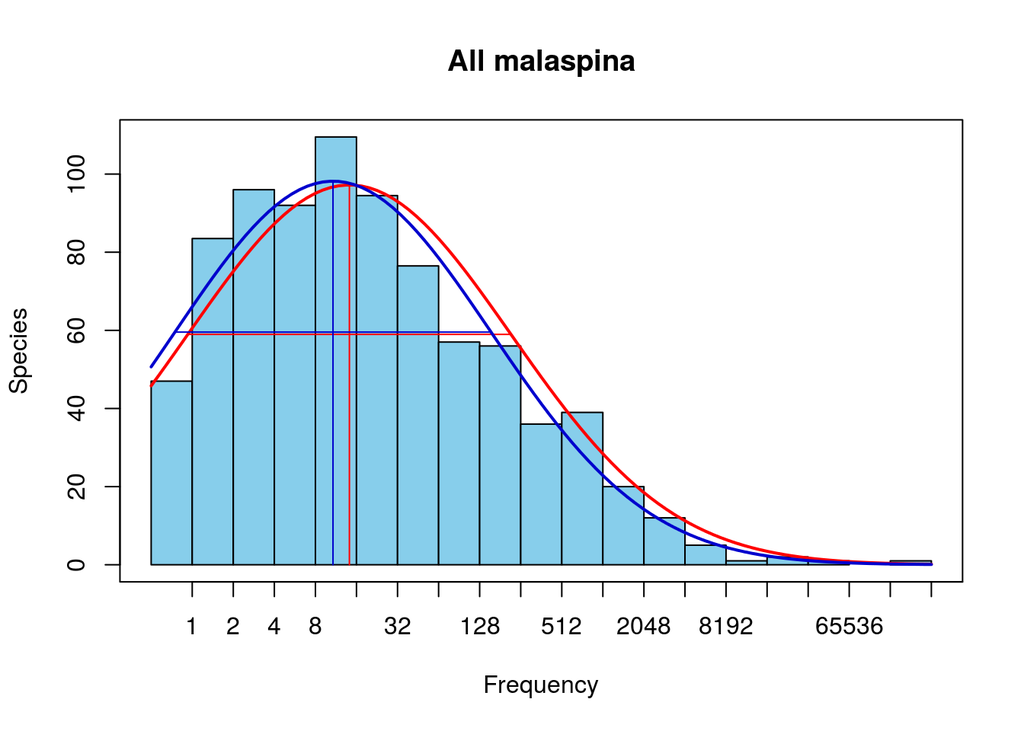

```
## Extrapolated     Observed       Veiled
##      947.412      829.000      118.412
```

## 3.6) Beta diversity

### 3.6.1) Dissimilarity matrix using Bray-Curtis index:

The Bray-Curtis dissimilarity, constrained between 0 (minimum distance) and 1 (highest dissimilarity) allows us to quantify the differences between samples according to the composition and relative abundance of their OTUs. In our dataset, most of the samples pairs take dissimilarity values between 0.35 and 0.55, meaning that their composition is quiet similar.

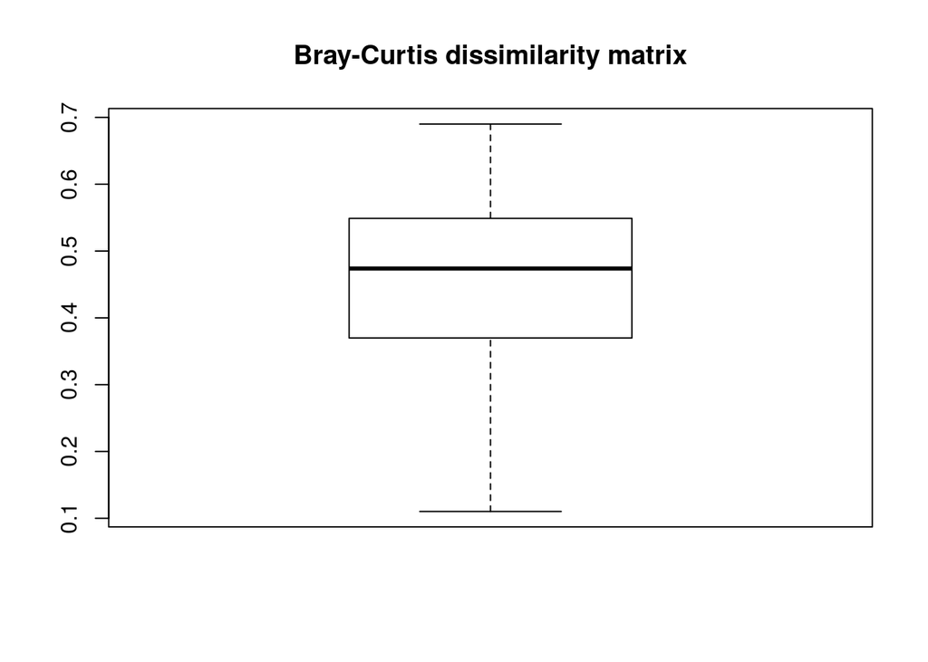

### 3.6.2) Hierarchical clustering

The only relatively evident clusters we can distinguish in the dendogram stand out in the very left side of the plot.

(To be done: assign Longhurst provinces information to each station and check if any of the central clusters is meaningful regarding to the samples’ geographical ubication)

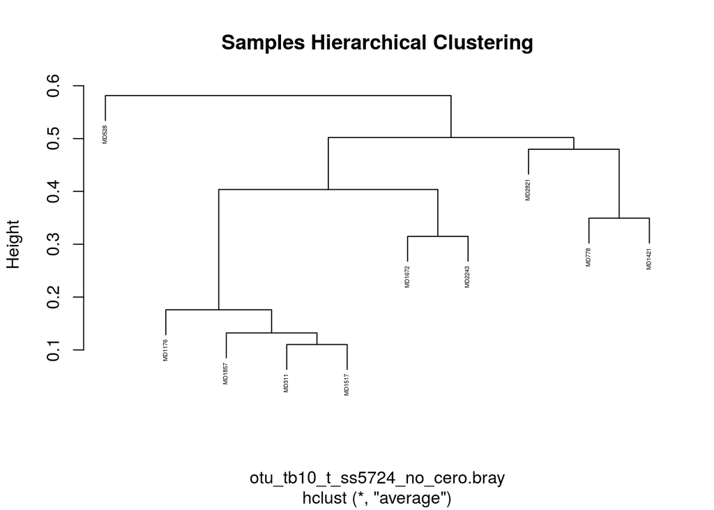

### 3.6.3) Non-metric multidimensional scaling

We can identify a prominent group in the middle-left side of the NMDS and a few isolated samples in the right edge of the plot. Considering the overall distribution, we’re not able to identify any informative clustering pattern.

The stress parameter takes a value below 0.3, meaning that the plot is valid.

```
##
## Call:
## monoMDS(dist = otu_tb10_t_ss5724_no_cero.bray)
##
## Non-metric Multidimensional Scaling
##
## 10 points, dissimilarity 'bray', call 'vegdist(x = otu_tb10_t_ss5724_no_cero, method = "bray")'
##
## Dimensions: 2
## Stress:     0.07667757
## Stress type 1, weak ties
## Scores scaled to unit root mean square, rotated to principal components
## Stopped after 41 iterations: Stress nearly unchanged (ratio > sratmax)
```

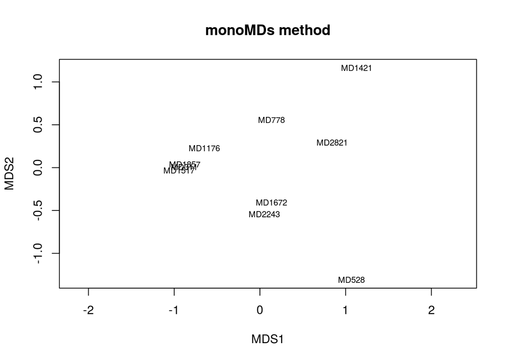

When implementing a most robut function for computing NMDS plots, the result is quiet the same:

```
## ... procrustes: rmse 2.034852e-05  max resid 3.763896e-05
## *** Solution reached
```

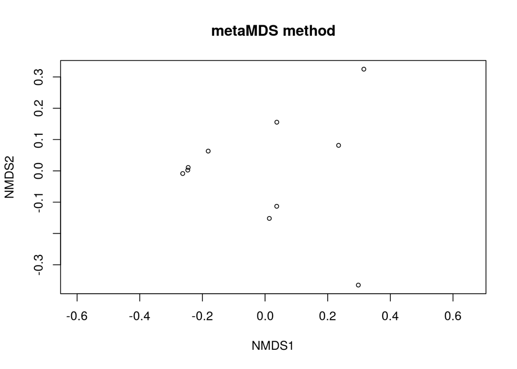

# 4) Geographical analysis

Working datasets:

1. Community matrix: otu_tb10_t_ss5724_no_cero

```r
dim(otu_tb10_t_ss5724_no_cero)
```

```
## [1]  10 591
```

```r
otu_tb10_t_ss5724_no_cero[1:5, 1:5]
```

```
##        OTU_5 OTU_1 OTU_596 OTU_1295 OTU_36
## MD311     18  3375       3        0     20
## MD528    269   467       6        0     18
## MD778    589  1501       3        0      2
## MD1176    26  3359       5        0      2
## MD1421   944   635      14        0      1
```

2. Community Bray-Curtis: otu_tb10_t_ss5724_no_cero.bray

```r
otu_tb10_t_ss5724_no_cero.bray<-as.matrix(otu_tb10_t_ss5724_no_cero.bray)
```

3. Stations distances in km: geo_distances_MP_10_ss5724

```r
dim(geo_distances_MP_10_ss5724)
```

```
## [1] 10 10
```

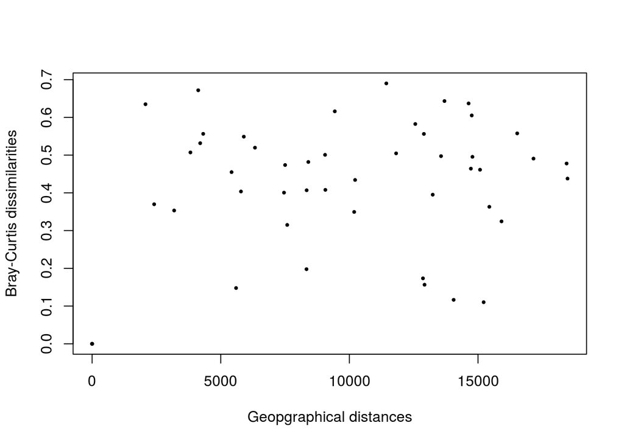

```r
plot(geo_distances_MP_10_ss5724, otu_tb10_t_ss5724_no_cero.bray, pch=19, cex=0.4, xlab="Geopgraphical distances", ylab="Bray-Curtis dissimilarities")
```

## 4.1) Mantel correlograms

When implementing the Mantel Test, we obtain a very low statistic, meaning that the correlation between samples dissimilarity and geographical distances is weak; besides, it is not significant, so we shouldn’t consider the test meaningful.

```r
mantel(geo_distances_MP_10_ss5724, otu_tb10_t_ss5724_no_cero.bray)
```

```
##
## Mantel statistic based on Pearson's product-moment correlation
##
## Call:
## mantel(xdis = geo_distances_MP_10_ss5724, ydis = otu_tb10_t_ss5724_no_cero.bray)
##
## Mantel statistic r: -0.07903
##       Significance: 0.737
##
## Upper quantiles of permutations (null model):
##   90%   95% 97.5%   99%
## 0.165 0.245 0.311 0.421
## Permutation: free
## Number of permutations: 999
```

Maximum distance between samples:

```
## [1] 18480.1
```

Minimum distance between samples:

```
## [1] 0
```

# 5) Abundance & occurence

In the following plot, we can appreciate the OTUs distribution according to their percentage of occurence and relative abundance. The red line keeps up OTUs that occur in more than 80% of the samples, the green line limits regionally rare OTUs (< 0.001%), and the blue one restricts regionally abundant OTUs (> 0.1%).

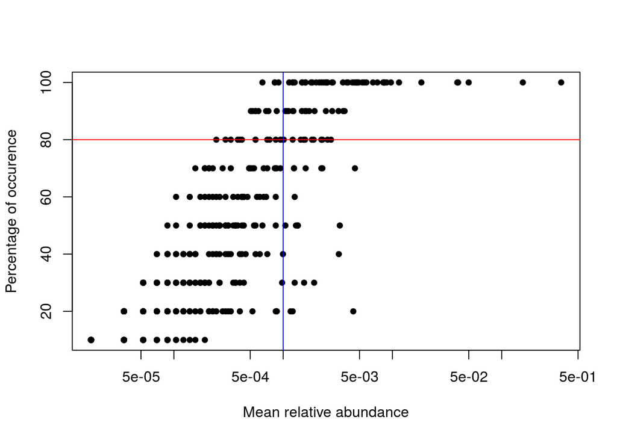

Regionally abundant OTUs (relative abundance over 0.1%):

```
##         mean_rabund perc_occur
## OTU_1   0.350331936        100
## OTU_2   0.156201957        100
## OTU_4   0.049895178        100
## OTU_3   0.039937107        100
## OTU_5   0.039273235        100
## OTU_6   0.018413697        100
## OTU_10  0.011495458        100
## OTU_23  0.009696017        100
## OTU_13  0.008857442        100
## OTU_368 0.008473096        100
## OTU_104 0.008420685        100
## OTU_552 0.008403215        100
## OTU_12  0.008385744        100
## OTU_9   0.008228512        100
## OTU_435 0.007285115        100
## OTU_28  0.006638714        100
## OTU_34  0.005782669        100
## OTU_11  0.005520615        100
## OTU_20  0.005310971        100
## OTU_198 0.004909154        100
## OTU_33  0.004786862        100
## OTU_14  0.004682041        100
## OTU_36  0.004664570        100
## OTU_40  0.004542278         70
## OTU_29  0.004472397        100
## OTU_61  0.004385045         20
## OTU_8   0.004297694        100
## OTU_25  0.003930818        100
## OTU_21  0.003825996        100
## OTU_19  0.003651293         90
## OTU_7   0.003546471         90
## OTU_234 0.003529001        100
## OTU_47  0.003301887         50
## OTU_79  0.003232006         40
## OTU_55  0.003214535         90
## OTU_70  0.002847659        100
## OTU_37  0.002812718         90
## OTU_102 0.002795248        100
## OTU_709 0.002742837         80
```

[output cut: 38 more lines]

```
## OTU_158 0.001257862         70
## OTU_43  0.001257862         70
## OTU_56  0.001240391         90
## OTU_147 0.001222921        100
## OTU_553 0.001222921        100
## OTU_87  0.001222921         90
## OTU_16  0.001222921         80
## OTU_227 0.001222921         20
## OTU_231 0.001170510         20
## OTU_82  0.001135570        100
## OTU_48  0.001118099         90
## OTU_91  0.001083159         90
## OTU_62  0.001048218         90
## OTU_109 0.001048218         50
## OTU_88  0.001013277         80
```

```r
dim(tb10_ss5724_abundant_sorted)
```

```
## [1] 92  2
```

Proportion of regionally abundant OTUs (%):

```
## [1] 15.56684
```

Cosmopolitan OTUs (abundance over 0.1% and occurence in more than 80% of samples):

```
##         mean_rabund perc_occur
## OTU_1   0.350331936        100
## OTU_2   0.156201957        100
## OTU_4   0.049895178        100
## OTU_3   0.039937107        100
## OTU_5   0.039273235        100
## OTU_6   0.018413697        100
## OTU_10  0.011495458        100
## OTU_23  0.009696017        100
## OTU_13  0.008857442        100
## OTU_368 0.008473096        100
## OTU_104 0.008420685        100
## OTU_552 0.008403215        100
## OTU_12  0.008385744        100
## OTU_9   0.008228512        100
## OTU_435 0.007285115        100
## OTU_28  0.006638714        100
## OTU_34  0.005782669        100
## OTU_11  0.005520615        100
## OTU_20  0.005310971        100
## OTU_198 0.004909154        100
## OTU_33  0.004786862        100
## OTU_14  0.004682041        100
## OTU_36  0.004664570        100
## OTU_29  0.004472397        100
## OTU_8   0.004297694        100
## OTU_25  0.003930818        100
## OTU_21  0.003825996        100
## OTU_234 0.003529001        100
## OTU_70  0.002847659        100
## OTU_102 0.002795248        100
## OTU_39  0.002550664        100
## OTU_15  0.002480783        100
## OTU_45  0.002480783        100
## OTU_69  0.002358491        100
## OTU_724 0.002253669        100
## OTU_654 0.002148847        100
## OTU_90  0.002009085        100
## OTU_247 0.001851852        100
## OTU_166 0.001799441        100
```

[output cut: 8 more lines]

```
## OTU_19  0.003651293         90
## OTU_7   0.003546471         90
## OTU_55  0.003214535         90
## OTU_37  0.002812718         90
## OTU_35  0.002463312         90
## OTU_177 0.001939203         90
## OTU_18  0.001729560         90
## OTU_84  0.001624738         90
## OTU_103 0.001589797         90
## OTU_89  0.001484976         90
## OTU_56  0.001240391         90
## OTU_87  0.001222921         90
## OTU_48  0.001118099         90
## OTU_91  0.001083159         90
## OTU_62  0.001048218         90
```

```r
dim(otu_tb10_ss5724_cosmop_sorted)
```

```
## [1] 62  2
```

Proportion of cosmopolitan OTUs (%):

```
## [1] 10.49069
```

Number and proportion (%) of rare OTUs:

```r
dim(otu_tb10_ss5724_rabund_percoccur[otu_tb10_ss5724_rabund_percoccur$mean_rabund < 0.00001 & otu_tb10_ss5724_rabund_percoccur$mean_rabund >0,])
```

```
## [1] 0 2
```

```
## [1] 0
```